# Reconstruções

Marcelo Reginato

Bioinformática aplicada à sistemática, biogeografia e macroevolução

Novembro / 2018

## Tutoriais

Uma boa introdução a tópicos filogenéticos no R:

http://www.springer.com/us/book/9781461417422

Alguns tutoriais:

http://www.anthrotree.info/wiki/projects/pica/The_AnthroTree_Website.html

https://www.r-phylo.org/wiki/HowTo/Table_of_Contents

http://www.phytools.org/eqg/Exercise_3.2/

## Pacotes necessários

```r
install.packages("ape", dependencies=T)
install.packages("phytools", dependencies=T)
install.packages("phangorn", dependencies=T)
install.packages("geiger", dependencies=T)
install.packages("surface", dependencies=T)
```

No entanto, um dos pacotes (phyloch) não está disponível no CRAN, e para instalá-lo é preciso fazer o download e depois instalar “from source”. Faça o download do pacote em:

http://www.christophheibl.de/phyloch_1.5-3.tar.gz

Para instalar o pacote “from source” no Rstudio, vá em “Tools” $\rightarrow$ “Install Packages” $\rightarrow$ mude a opção para instalar de “Package archive file”, e seleciono o arquivo tar.gz file. É possível também instalar diretamente por um comando (mudando o endereço do arquivo tar.gz file):

```r
install.packages("C:/Users/Marcelo/Downloads/phyloch_1.5-3.tar.gz", repos = NULL, type = "source")
```

Carregando os pacotes.

```r
library(ape)
library(phytools)
library(phangorn)
library(phyloch)
library(geiger)
```

## Importando os dados

Neste tutorial iremos utilizar os dados “geospiza” do pacote geiger.

```r
### Set your working directory
setwd("~/My_working_direcory")
```

```r
### Import the tree
read.tree("geospiza.tre") -> tree
```

Esta árvore esta em formato newick. Por isso utilizamos a função “read.tree”. Caso a árvore estivesse em formato “nexus” a função utilizada para importar seria “read.nexus”

## Plotando árvores

Seguem algumas opções de plots/manipulação de árvores com funções do pacote ape

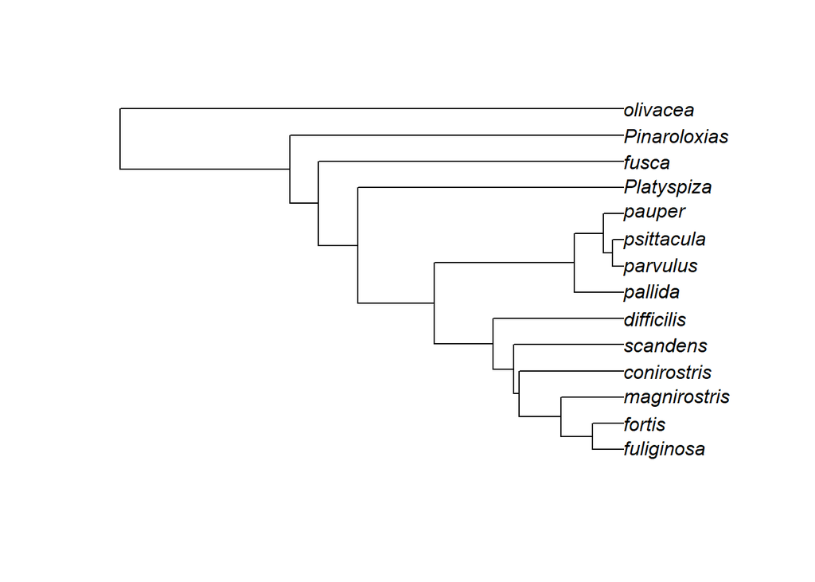

```r
### Plotting
plot(tree)
```

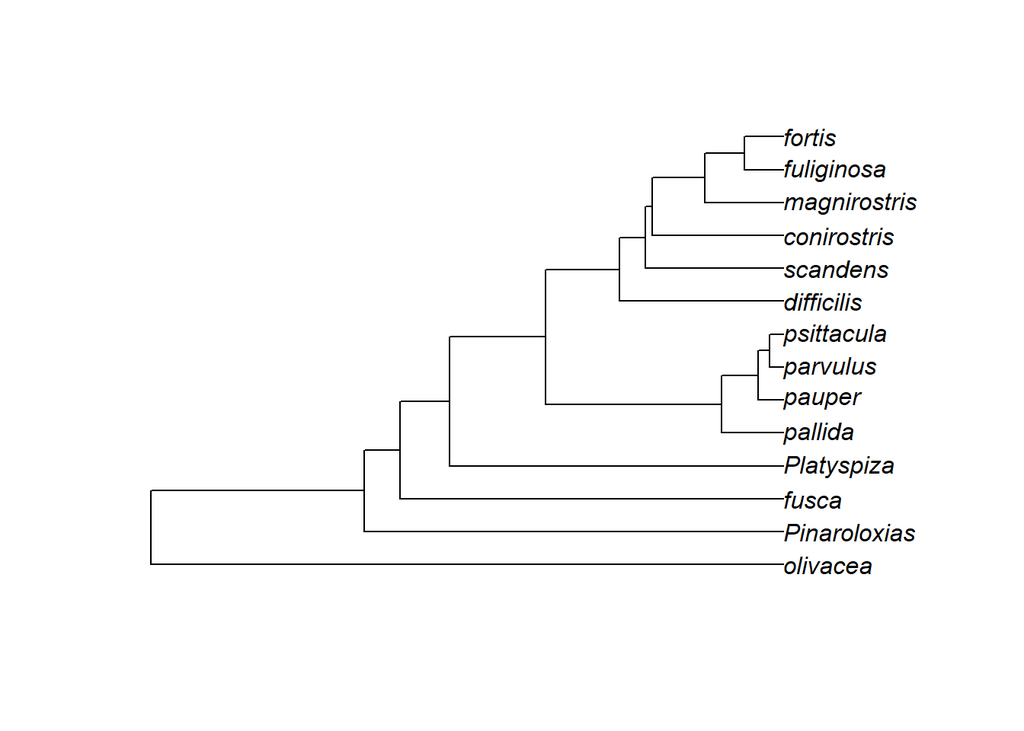

```r
### Ladderize
ladderize(tree, right=F) -> tree.l
plot(tree.l)
```

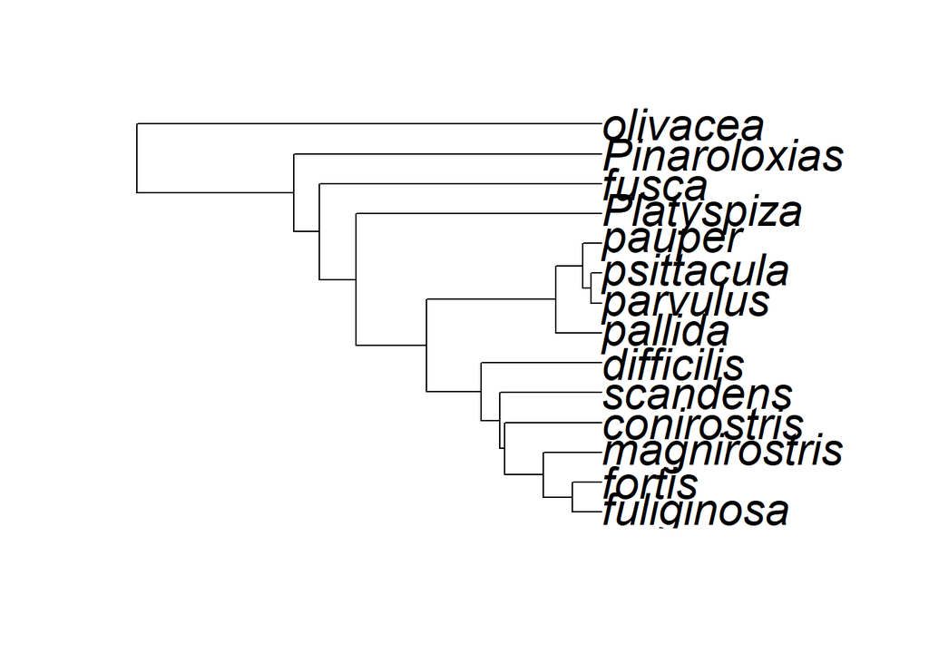

```r
### Mudar o tamanho dos tips.
plot(tree, cex=2)
```

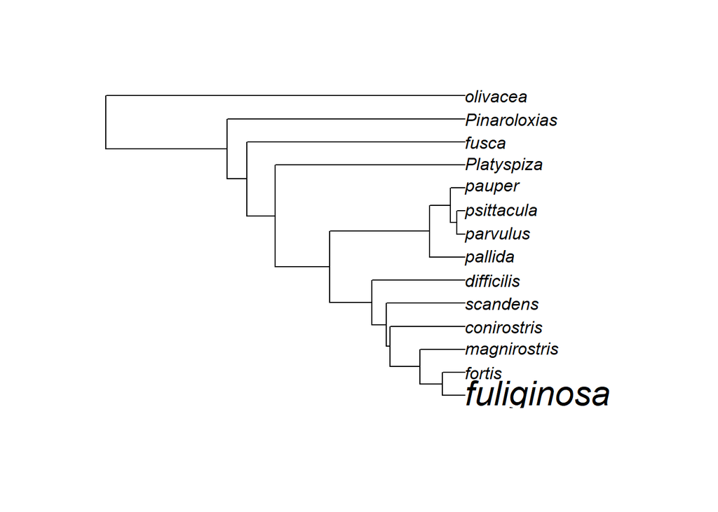

```r
### Mudar com diferentes tamanhos
sizes <- c(2, rep(1, Ntip(tree)-1))
plot(tree, cex=sizes)
```

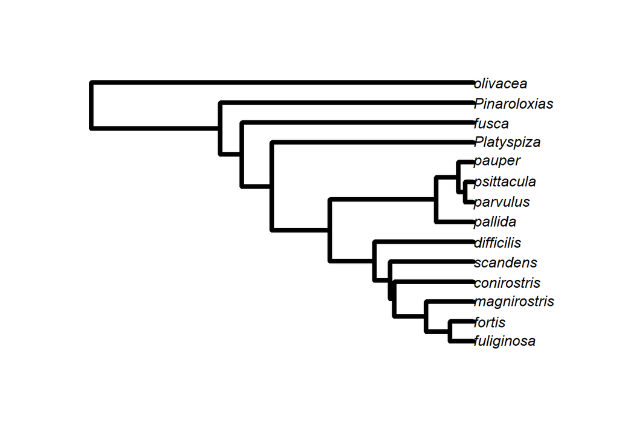

```r
### Mudar a espessura do ramo
plot(tree, edge.width = 5)
```

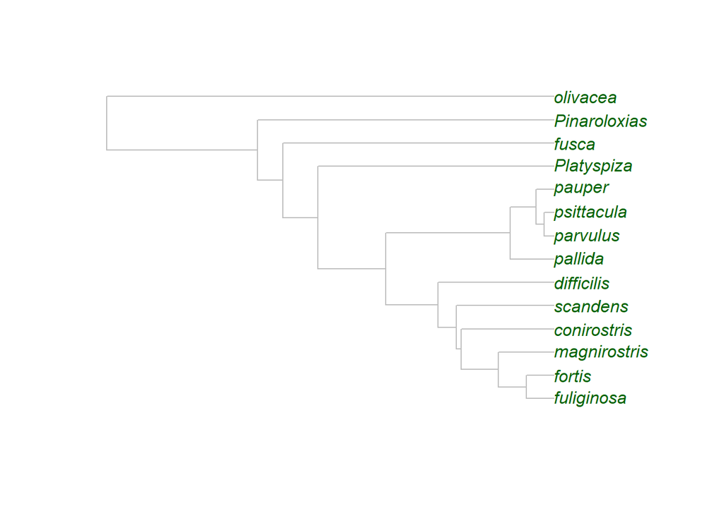

```r
### Mudar a cor dos ramos e tips
plot(tree, edge.color = "gray", tip.color = "darkgreen")
```

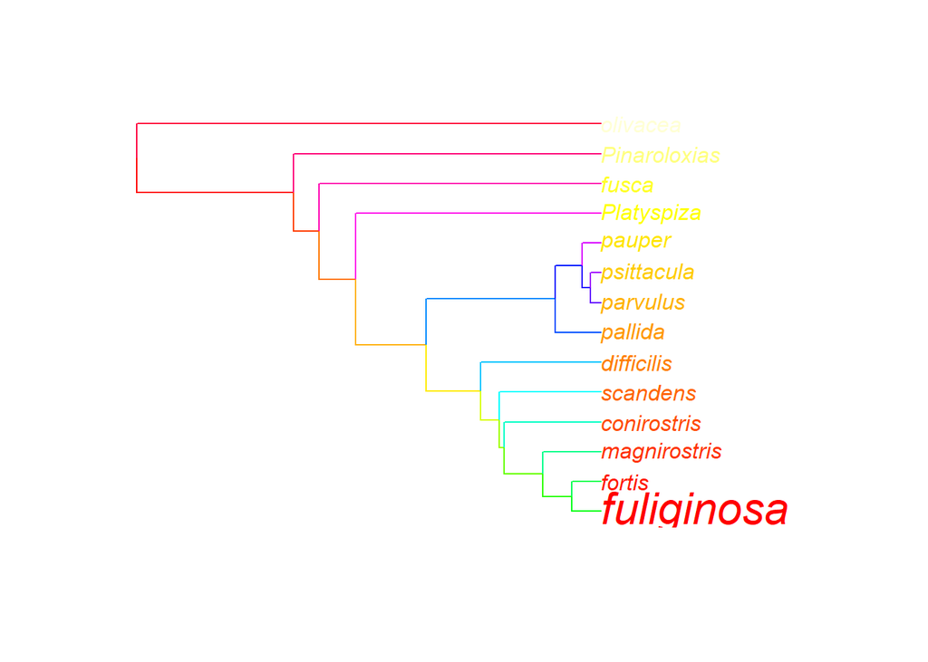

```r
### Mudar a cor de todos
heat.colors(Ntip(tree)) -> tipcols
rainbow(Nedge(tree)) -> edgecols
plot(tree, edge.color=edgecols, tip.color=tipcols, cex=sizes)
```

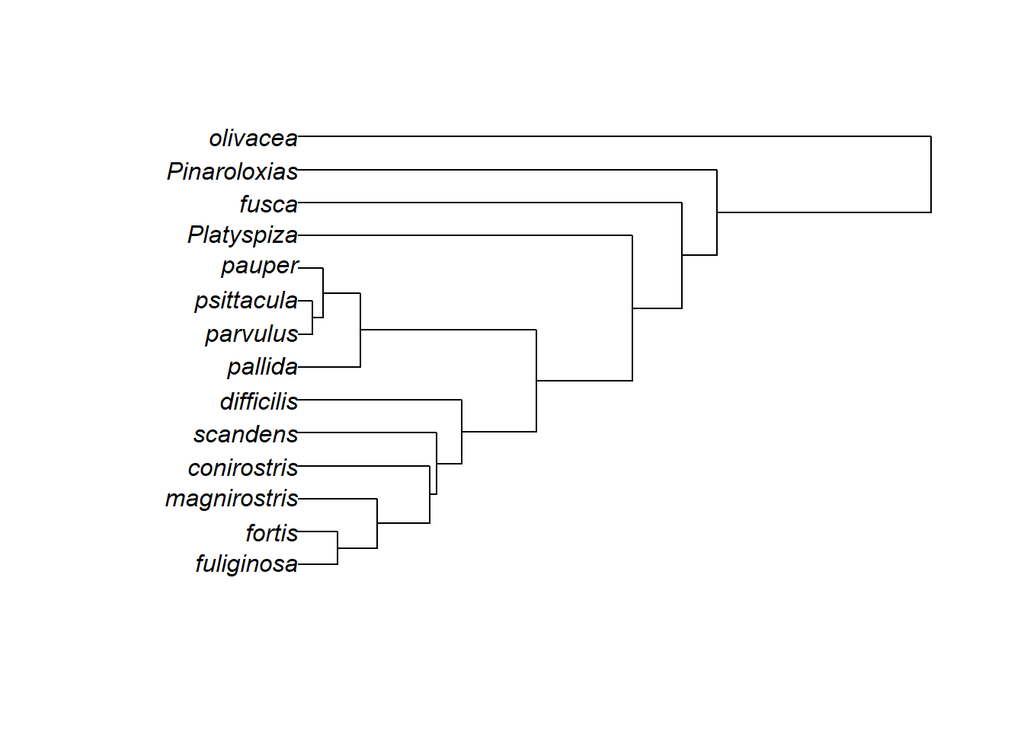

```r
### Mudar a direção

plot(tree, direction="leftwards")
```

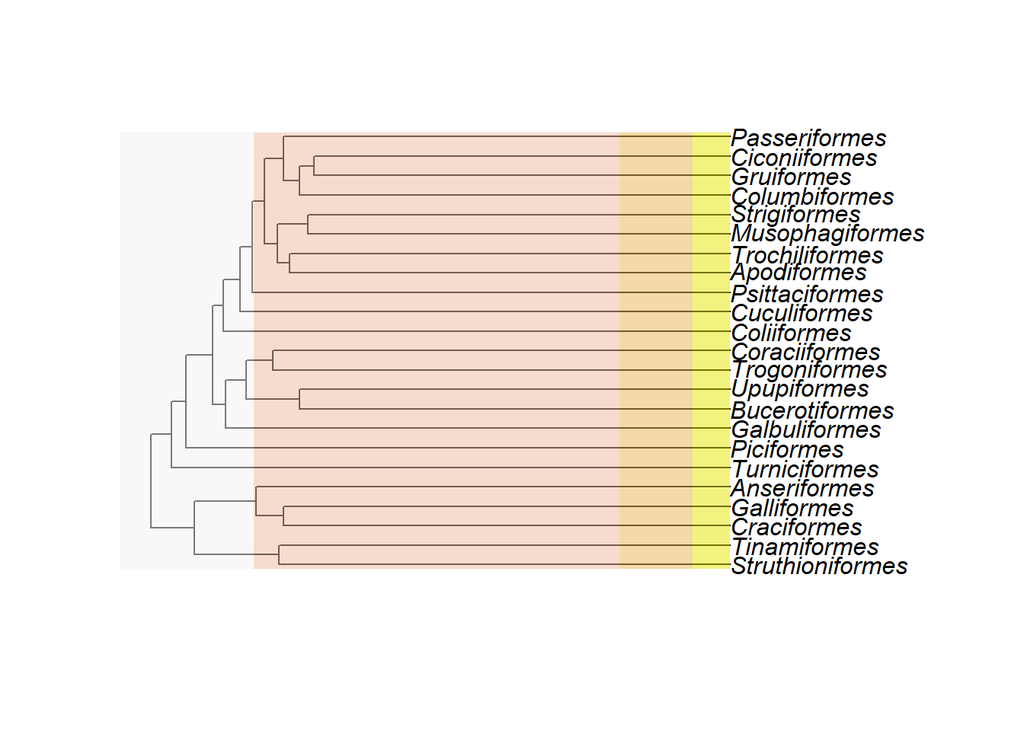

```r
### Adicionar uma escala
data(bird.orders)
data(strat2012)

plot(bird.orders)
add.geoscale(bird.orders)
```

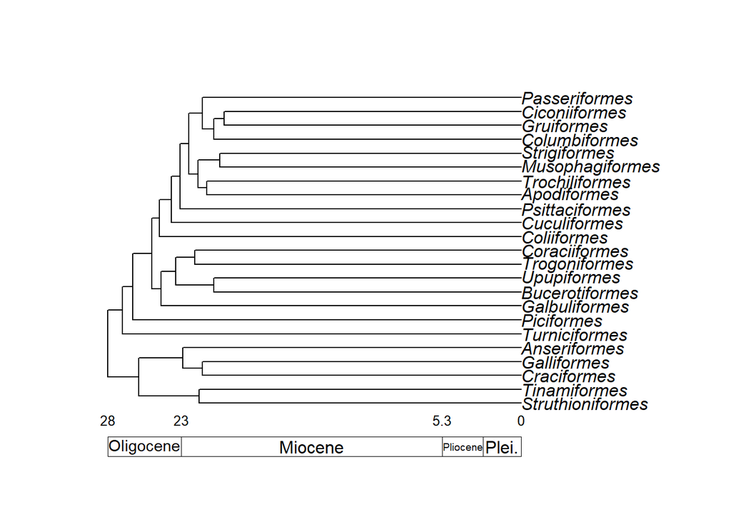

```
##
## Plot unit: epoch
## Stage 1: 7
## Stage 2: 22
## Stage 3: 23
## Stage 4: 13
## Stage 5: 17
```

```r
plot(bird.orders)
axisGeo(strat2012, unit="epoch")
```

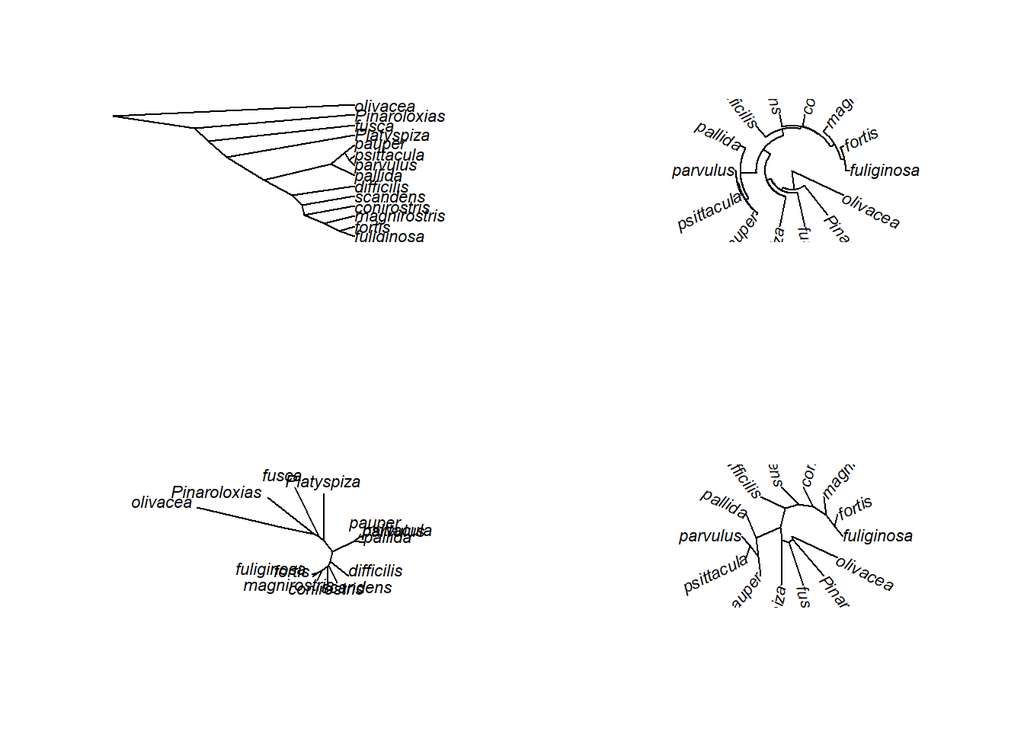

```r
### Mudar o tipo do plot

par(mfrow=c(2,2))

plot(tree, type="cladogram")
plot(tree, type="fan")
plot(tree, type="unrooted")
plot(tree, type="radial")
```

## Manipulando árvores

Acessando informações sobre a árvore

```r
### quantos tips?
Ntip(tree)
```

```
## [1] 14
```

```r
### quantos nós?
Nnode(tree)
```

```
## [1] 13
```

```r
### é enraizada?
is.rooted(tree)
```

```
## [1] TRUE
```

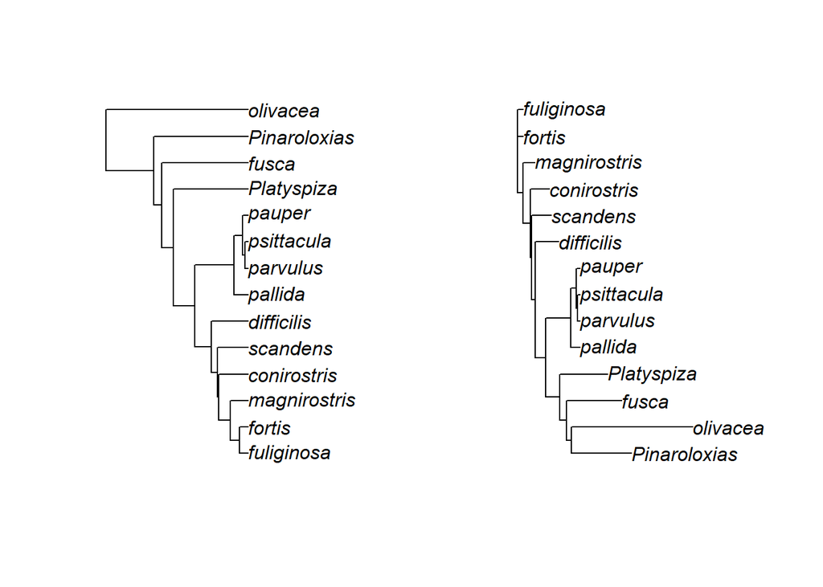

```r
### É possível enraizar a árvore no R
root(tree, "fuliginosa", resolve.root=T) -> rtree
par(mfrow=c(1,2))
plot(tree)
plot(rtree)
```

```r
### é binária (fully resolved)?
is.binary.tree(tree)
```

```
## [1] TRUE
```

```r
### é ultramétrica?
is.ultrametric(tree)
```

```
## [1] TRUE
```

```r
### Acessar o comprimento dos ramos
tree$edge.length
```

```
##  [1] 0.29744 0.04924 0.06859 0.13404 0.10346 0.03550 0.00917 0.07333
##  [9] 0.05500 0.05500 0.05500 0.11000 0.18333 0.19250 0.22800 0.24479
## [17] 0.08667 0.05167 0.01500 0.02000 0.02000 0.03500 0.46550 0.53409
## [25] 0.58333 0.88077
```

```r
mean(tree$edge.length)
```

```
## [1] 0.1764008
```

```r
### Acessar o nome dos tips
tree$tip.label
```

```
##  [1] "fuliginosa"   "fortis"       "magnirostris" "conirostris"
##  [5] "scandens"     "difficilis"   "pallida"      "parvulus"
##  [9] "psittacula"   "pauper"       "Platyspiza"   "fusca"
## [13] "Pinaroloxias" "olivacea"
```

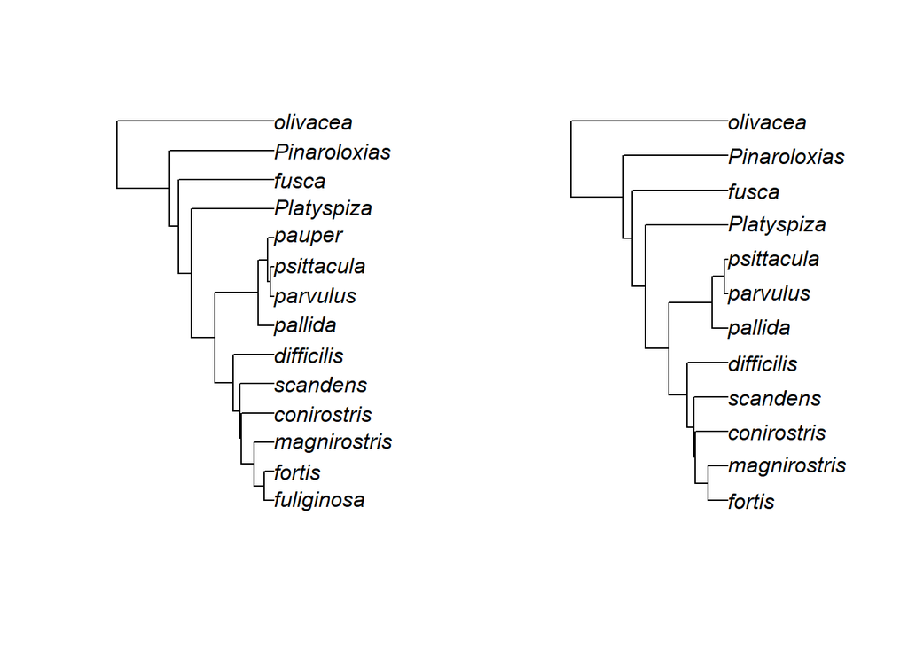

```r
### Remover um ou mais tips
drop.tip(tree, tip=c("fuliginosa", "pauper")) -> dtree

plot(tree)
plot(dtree)
```

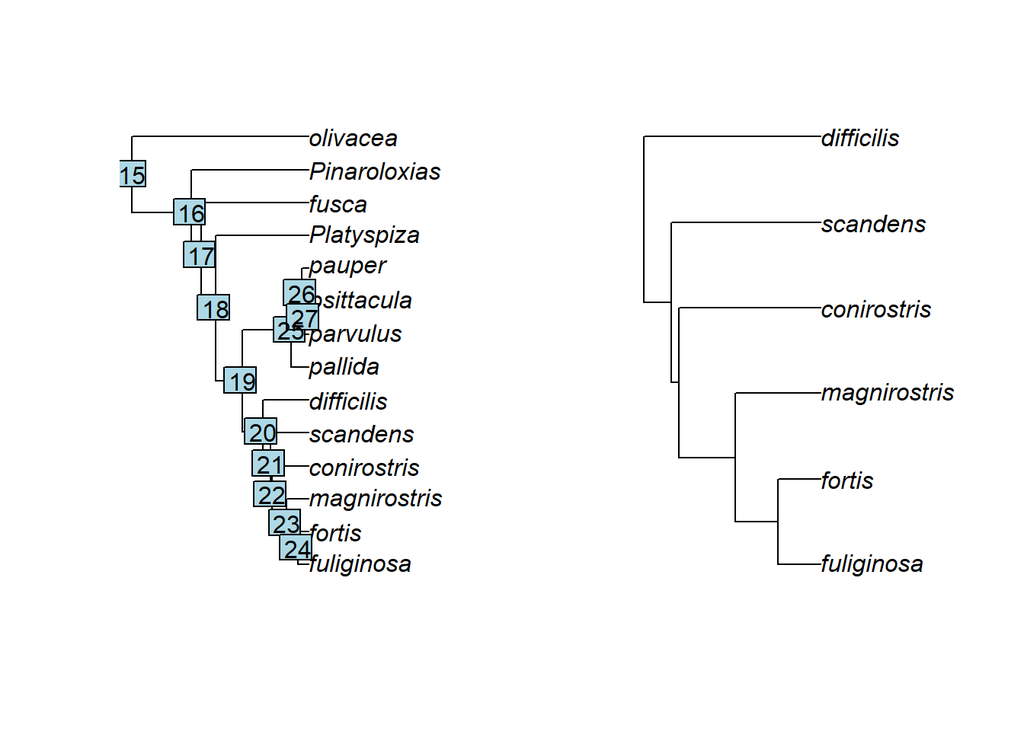

```r
### Com a função nodelabels() é possivel conferir o número dos nós
plot(tree)
nodelabels()

### Com o número dos nós é possível realizar várias tarefas, por exemplo extrair um sub-clado
extract.clade(tree, 20) -> etree
plot(etree)
```

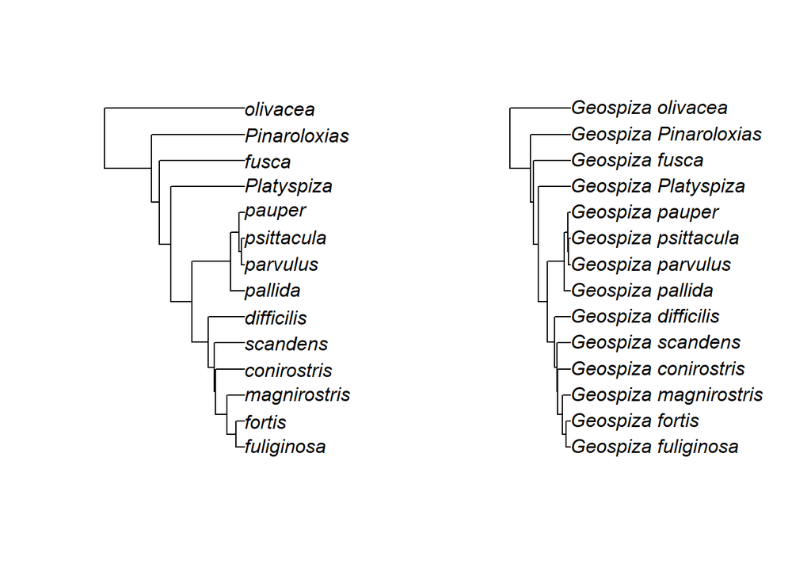

```r
### Alterando o nome dos tips.
new.labs <- paste("Geospiza", tree$tip.label, sep="_")
tree -> ntree
ntree$tip.label <- new.labs
plot(tree)
plot(ntree)
```

```r
dev.off()
```

## Filogenia e dados

Para realizar qualquer análise utilizado árvore e dados, primeiro é preciso deixar os dados e a árvore “paralelos” (com os mesmos nomes e na mesma ordem)

```r
### Importando os dados morfológicos

read.table("geospiza_data.txt", sep="\t", header = T) -> morpho
head(morpho)
```

```
##                 wingL  tarsusL  culmenL    beakD   gonysW
## magnirostris 4.404200 3.038950 2.724667 2.823767 2.675983
## conirostris  4.349867 2.984200 2.654400 2.513800 2.360167
## difficilis   4.224067 2.898917 2.277183 2.011100 1.929983
## scandens     4.261222 2.929033 2.621789 2.144700 2.036944
## fortis       4.244008 2.894717 2.407025 2.362658 2.221867
## fuliginosa   4.132957 2.806514 2.094971 1.941157 1.845379
```

```r
### Checar se os nomes dos dados e da filogenia são iguais
cbind(tree$tip.label, rownames(morpho))
```

```
##       [,1]           [,2]
##  [1,] "fuliginosa"   "magnirostris"
##  [2,] "fortis"       "conirostris"
##  [3,] "magnirostris" "difficilis"
##  [4,] "conirostris"  "scandens"
##  [5,] "scandens"     "fortis"
##  [6,] "difficilis"   "fuliginosa"
##  [7,] "pallida"      "pallida"
##  [8,] "parvulus"     "fusca"
##  [9,] "psittacula"   "parvulus"
## [10,] "pauper"       "pauper"
## [11,] "Platyspiza"   "Pinaroloxias"
## [12,] "fusca"        "Platyspiza"
## [13,] "Pinaroloxias" "psittacula"
## [14,] "olivacea"     "magnirostris"
```

```r
nrow(morpho) == length(tree$tip.label)
```

```
## [1] FALSE
```

```r
### Entao, temos um problema. Os dois não sao paralelos. Para resolver isso seria possível usar "match" e "drop.tip" para remover as espécies excedentes. Mas tem uma função que faz isso.

treedata(tree, morpho, sort=T) -> treedata
class(treedata)
```

```
## [1] "list"
```

```r
attributes(treedata)
```

```
## $names
## [1] "phy"  "data"
```

```r
treedata$phy -> tree
treedata$dat -> morpho
tree$tip.label == rownames(morpho)
```

```
##  [1] TRUE TRUE TRUE TRUE TRUE TRUE TRUE TRUE TRUE TRUE TRUE TRUE TRUE
```

Plontando a árvore com os dados

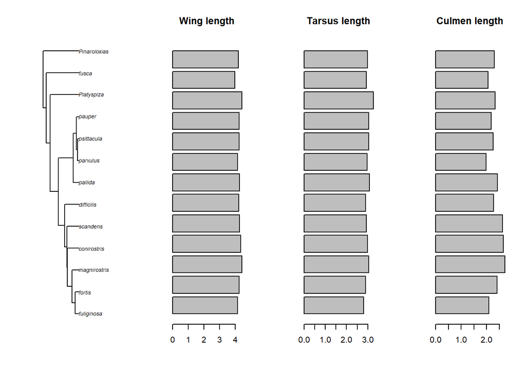

```r
par(mfrow=c(1,4))
plot(tree)
barplot(morpho[,1], horiz = T, names.arg=NA)
title("Wing length")
barplot(morpho[,2], horiz = T, names.arg=NA)
title("Tarsus length")
barplot(morpho[,3], horiz = T, names.arg=NA)
title("Culmen length")
```

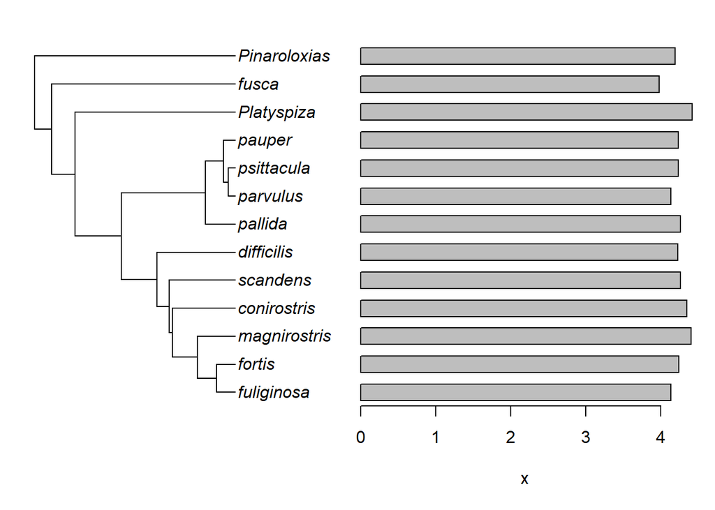

```r
wing <- morpho[,1]
names(wing) <- rownames(morpho)
plotTree.barplot(tree, wing)
```

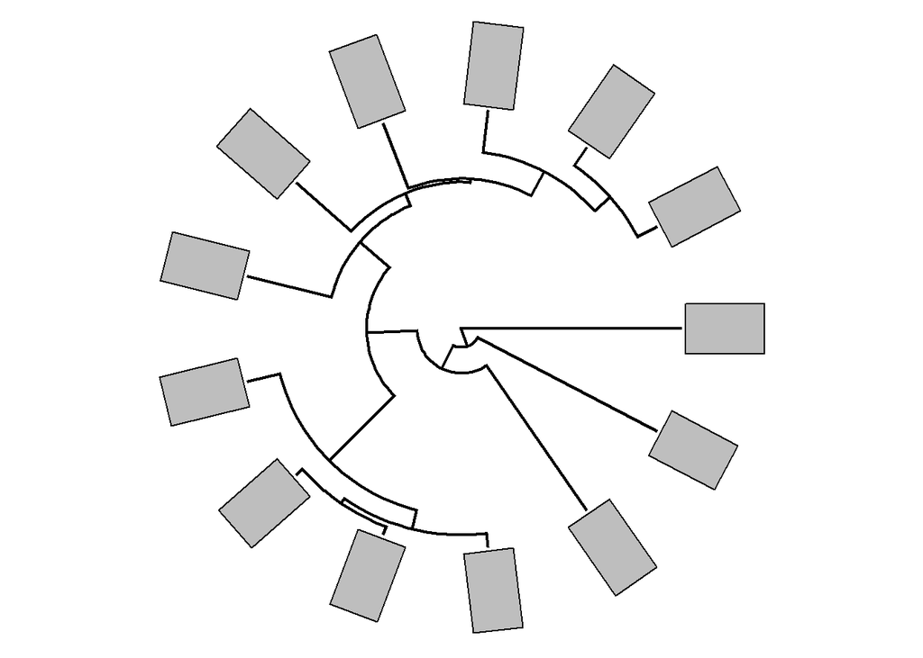

```r
par(mfrow=c(1,1))

plotTree.wBars(tree, wing, type="fan", scale=0.05)
```

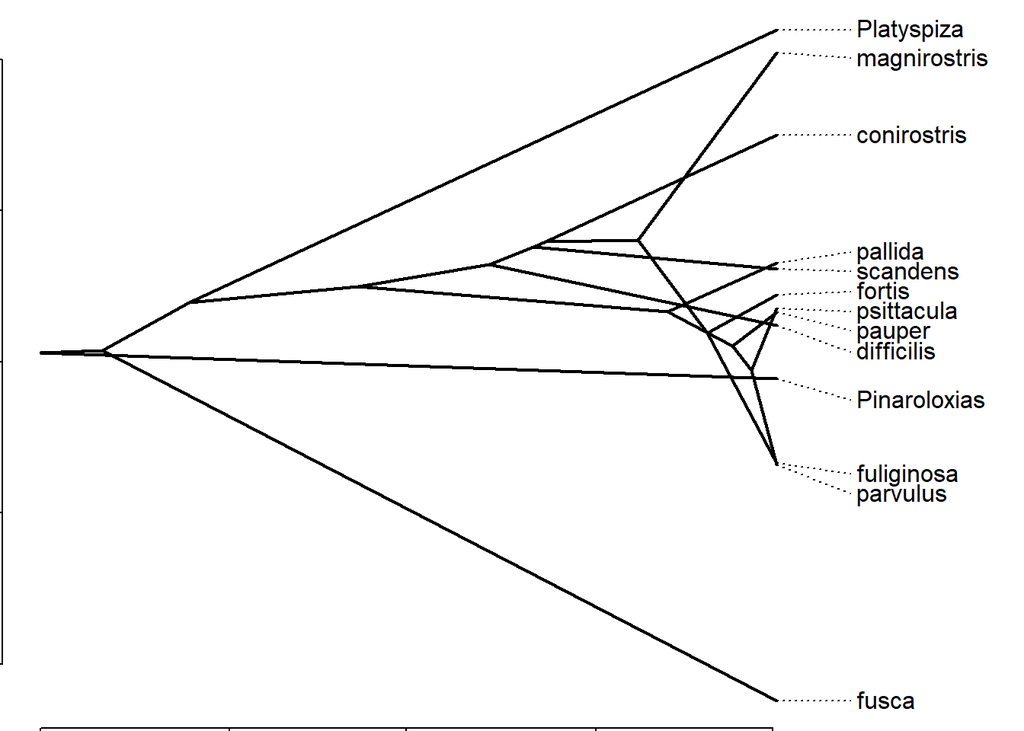

```r
phenogram(tree, wing)
```

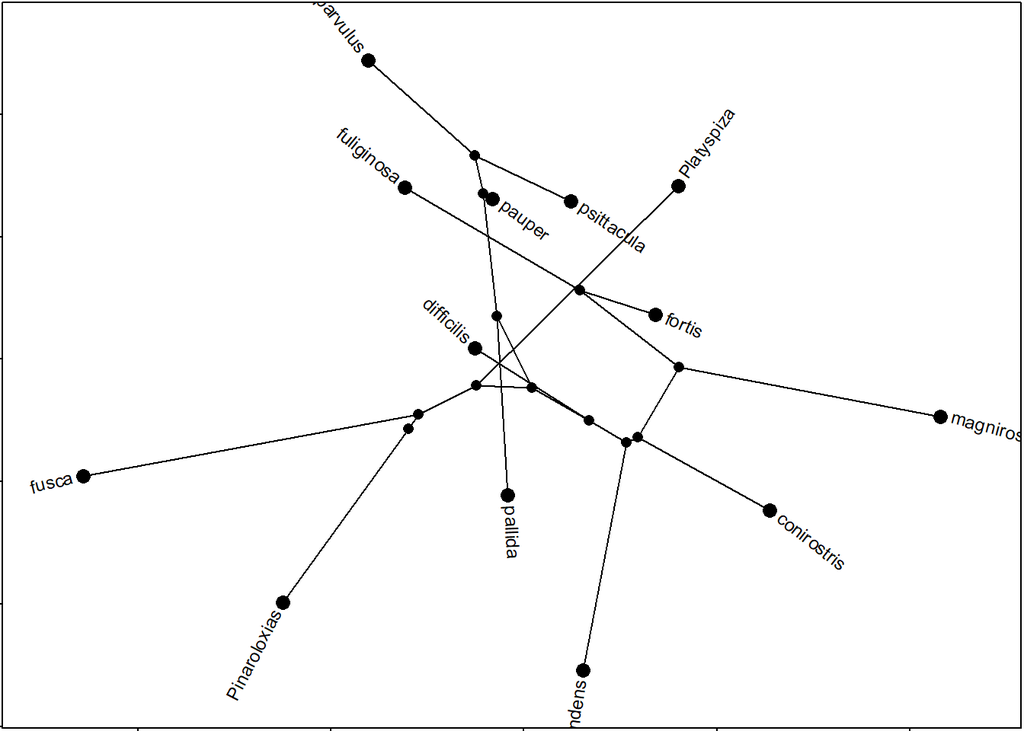

```r
### Um "phylo morphospace"

prcomp(morpho) -> pca.out
pca.out$x -> coords

phylomorphospace(tree, X=coords[,1:2])
```

```r
#fancyTree(tree, type="traitgram3d", X=coords[,1:2])
```

## Nodelabels e tiplabels

Tanto nodelabels() como tiplabels() podem ser usadas para plotar texto, gráficos “pie” e “thermo” sobre os nós e tips da árvore.

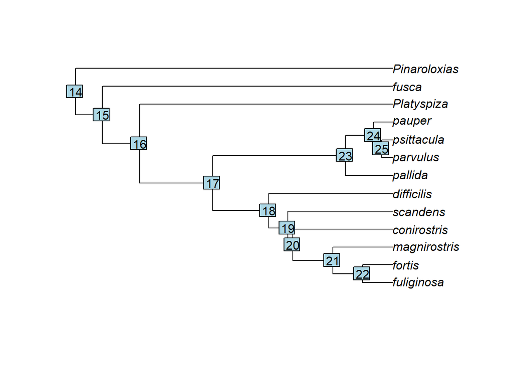

```r
plot(tree)
nodelabels()
```

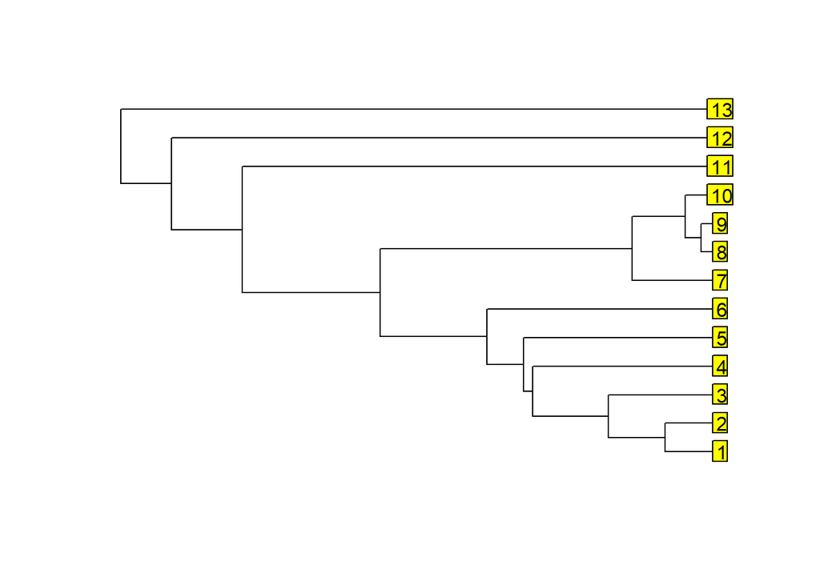

```r
plot(tree, show.tip.label=F)
tiplabels()
```

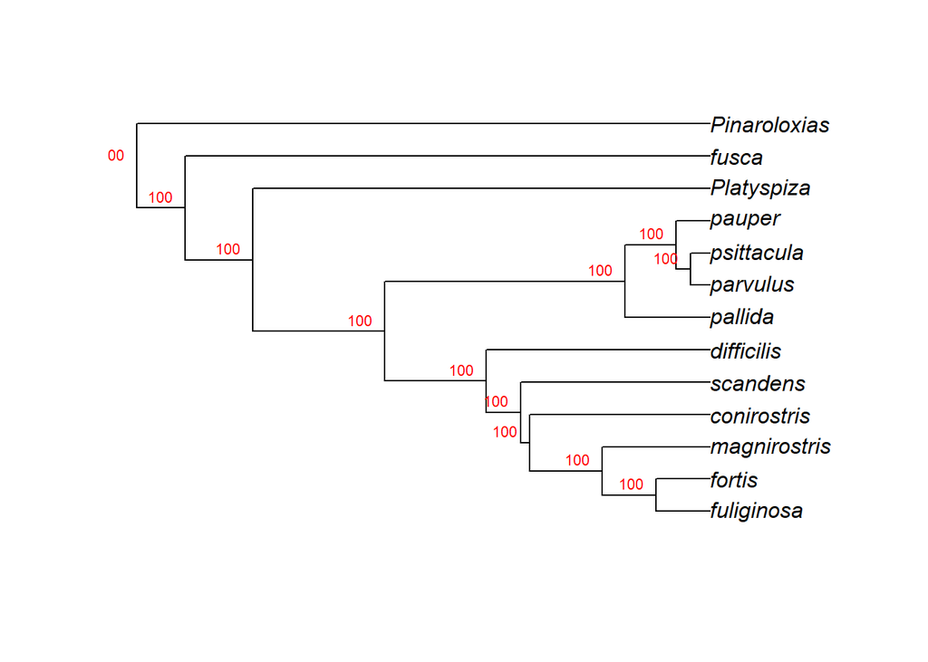

```r
### Vamos criar um vetor de valores de suporte "fake" para plotar sobre a árvore

support <- rep(100, Nnode(tree))
plot(tree)
nodelabels(support, frame="none", col="red", cex=0.7, adj=c(1.5,-0.5))
```

```r
### Vamos binarizar um caractere e plotá-lo com a árvore

wing.bin <- morpho[,1]
wing.bin[wing.bin <= mean(morpho[,1])] <- 0
wing.bin[wing.bin > mean(morpho[,1])] <- 1
names(wing.bin) <- rownames(morpho)
wing.bin
```

```
##   fuliginosa       fortis magnirostris  conirostris     scandens
##            0            1            1            1            1
##   difficilis      pallida     parvulus   psittacula       pauper
##            0            1            0            0            0
##   Platyspiza        fusca Pinaroloxias
##            1            0            0
```

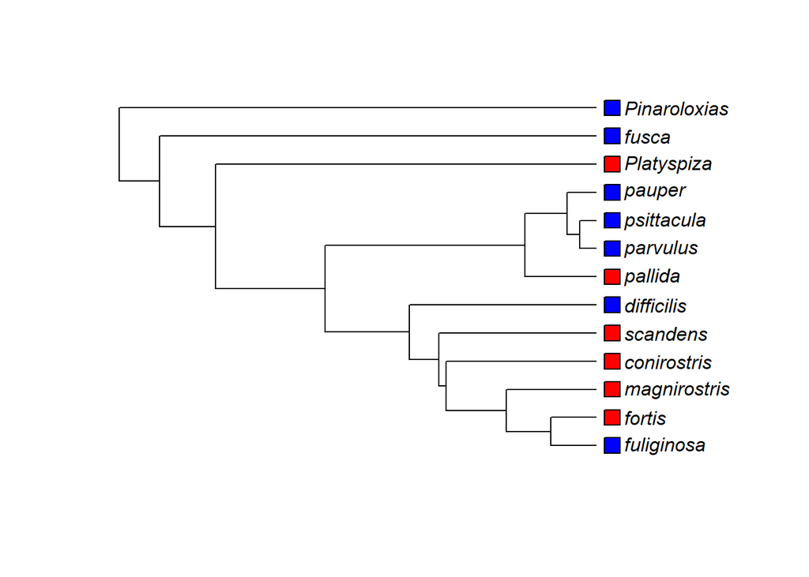

```r
wing.bin -> wing.bin.cols
wing.bin.cols[wing.bin == 0] <- "blue"
wing.bin.cols[wing.bin == 1] <- "red"

plot(tree, label.offset=0.035)
tiplabels(text=NULL, pch=22, adj=0.52, bg=wing.bin.cols, cex=2)
```

## Sinal filogenético

Vamos estimar o sinal filogenético de algum caractere utilizando a função “phylosig”.

```r
wing <- morpho[,1]
names(wing) <- rownames(morpho)
phylosig(tree, wing, method="K") -> k.sig
phylosig(tree, wing, method="lambda") -> l.sig

k.sig
```

```
## [1] 0.4214311
```

```r
l.sig
```

```
## $lambda
## [1] 0.6262253
##
## $logL
## [1] 9.729565
```

## Reconstruções

### Caracteres discretos

Existem várias funções para reconstruir caracteres discretos no R. Seguem exemplos utilizando duas delas.

```r
### First let's use "ace" from ape package. It has three model options and we are going to reconstruct our wing length binary character
ace.out <- ace(wing.bin, tree, type="discrete")

ace.out
```

```
##
##     Ancestral Character Estimation
##
## Call: ace(x = wing.bin, phy = tree, type = "discrete")
##
##     Log-likelihood: -7.821945
##
## Rate index matrix:
##   0 1
## 0 . 1
## 1 1 .
##
## Parameter estimates:
##  rate index estimate std-err
##           1   9.0169  6.5139
##
## Scaled likelihoods at the root (type '...$lik.anc' to get them for all nodes):
##         0         1
## 0.4999968 0.5000032
```

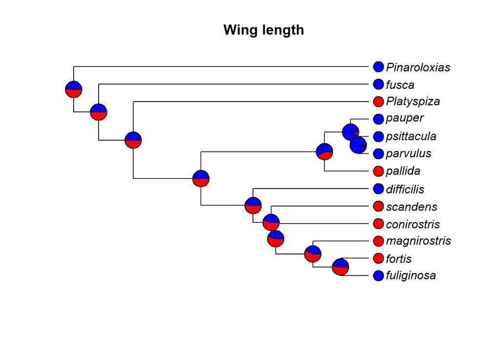

```r
### Plot

plot(tree, label.offset=0.035)
tiplabels(text=NULL, pch=21, adj=0.52, bg=wing.bin.cols, cex=2)
nodelabels(pie = ace.out$lik.anc, piecol = c("blue", "red"), cex = 1)
title("Wing length")
```

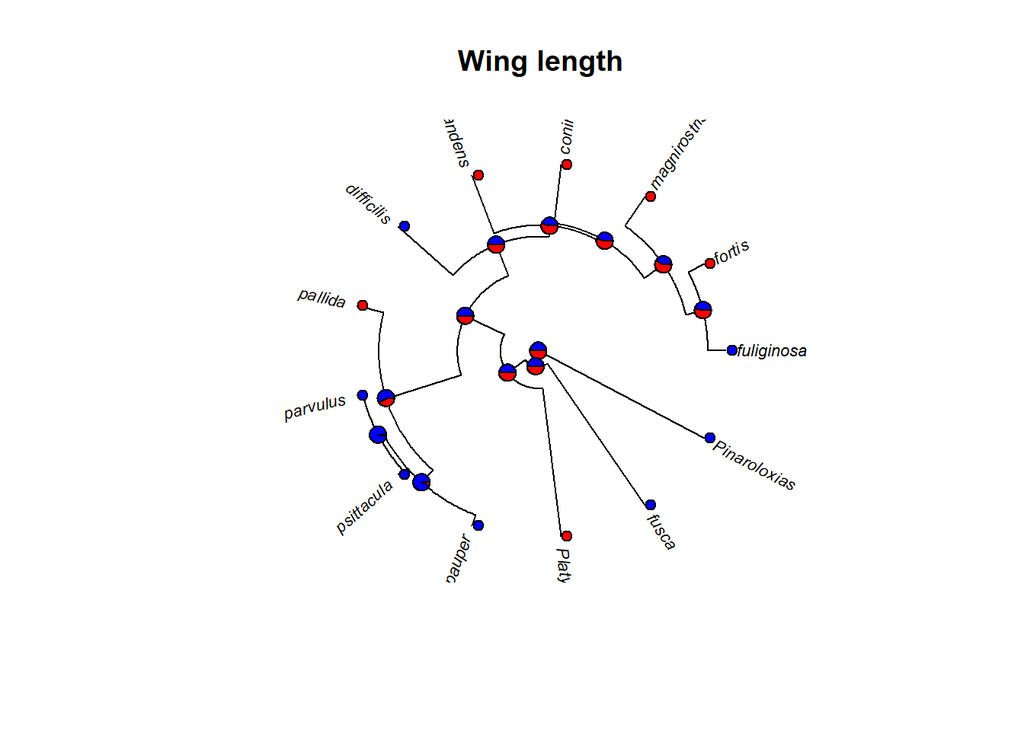

```r
### Plot alternativo

plot(tree, label.offset=0.035, type="fan", cex=0.7)
tiplabels(text=NULL, pch=21, adj=0.52, bg=wing.bin.cols, cex=1)
nodelabels(pie = ace.out$lik.anc, piecol = c("blue", "red"), cex = 0.5)
title("Wing length")
```

Outra opção é com mapas estocásticos

```r
atrees<-make.simmap(tree, wing.bin, nsim=100, model="ER")
```

```
## make.simmap is sampling character histories conditioned on the transition matrix
##
## Q =
##           0         1
## 0 -9.016884  9.016884
## 1  9.016884 -9.016884
## (estimated using likelihood);
## and (mean) root node prior probabilities
## pi =
##   0   1
## 0.5 0.5
```

```
## Done.
```

```r
countSimmap(atrees)$Tr -> count.out
colMeans(count.out)
```

```
##     N   0,0   0,1   1,0   1,1
## 30.48  0.00 15.27 15.21  0.00
```

```
## 100 trees with a mapped discrete character with states:
##  0, 1
##
## trees have 30.48 changes between states on average
##
## changes are of the following types:
##        0,1   1,0
## x->y 15.27 15.21
##
## mean total time spent in each state is:
##              0         1   total
## raw  1.6745714 1.7336386 3.40821
## prop 0.4913346 0.5086654 1.00000
```

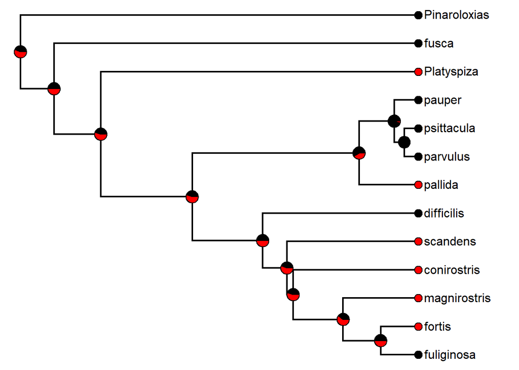

```r
simmap.wing <-describe.simmap(atrees,message=T, plot=T)
```

```r
densityMap(atrees)
```

```
## sorry - this might take a while; please be patient
```

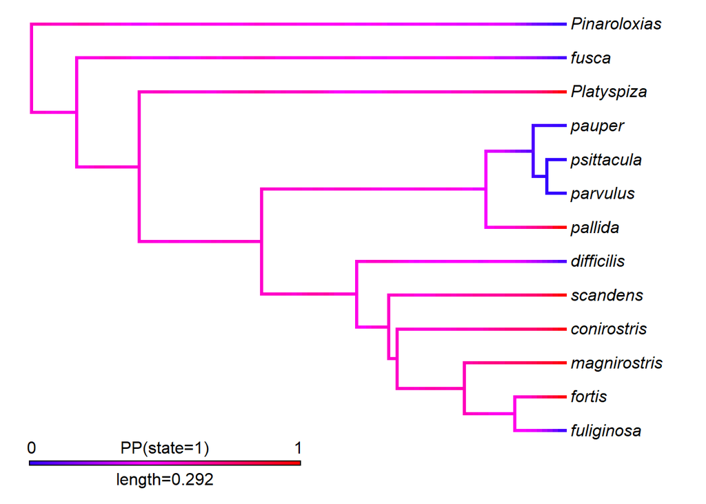

### Continuous characters

Para caracteres contínuos também existem diversas opções. Seguem exemplos de duas.

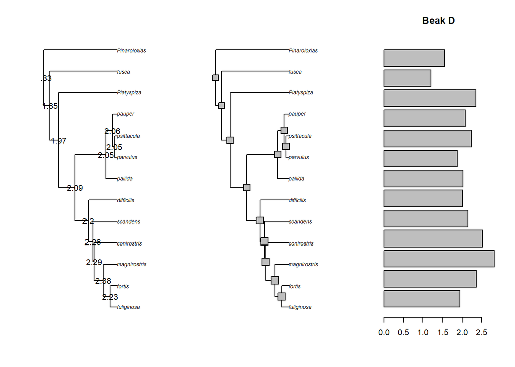

```r
### com "ace"

beakD <- morpho[,4]
names(beakD) <- rownames(morpho)

BM.ace <- ace(beakD, tree, type = "continuous", method = "ML", model = "BM")
par(mfrow=c(1,3))
plot(tree)
nodelabels(round(BM.ace$ace, 2), frame="none")
plot(tree)
nodelabels(pch = 22, cex=BM.ace$ace, bg="gray")
barplot(morpho[,4], horiz = T, names.arg=NA)
title("Beak D")
```

Outra opção é com contMap

```r
dev.off()
```

```r
contMap(tree, beakD) -> beak.contmap

plot(beak.contmap)

### Exportando o plot

pdf(file="ACE_wing.pdf", width=5, height=8)
plot(beak.contmap)
dev.off()
```

[output not shown]